# Practical Machine Learning - Course Project

Guohong He

2/15/2021

### I Overview

This is the final report for Coursera’s Practical Machine Learning course. In this report, we use data from accelerometers on the belt, forearm, arm, and dumbell of 6 participants to quantify how well they do it, which is marked in variable “*classe*” in traing data set.

First, we will do data wrangling, such as removing variables with most being NAs, proceeding correlation and multi-collinearity analysis between variables, and removing near zero variance variables. Then, we will build four classification models by using k-folds cross validation on training data set. They are *Decision Tree Model*, *Random Forest Model*, *Gradient Boosting Model*, *Gradient Boosting Model* and *Support Vector Machine Model*. The accuracy from these models on validation data prediction will be used for model selection. In the end, the model with the best accuracy is used to predict test data set.

### II Background

It is now possible to collect a large amount of data about personal activity relatively inexpensively by using devices such as Jawbone Up, Nike FuelBand, and Fitbit, even smart phones. These data can provide information to improve people’s health, to find patterns in their behavior, to correct their movements, and to prevent some fatal accidents, such as falls of elder people.

In this project report, we use data from accelerometers on the belt, forearm, arm, and dumbell of 6 participants to quantify how well they do it. They were asked to perform barbell lifts correctly and incorrectly in 5 different ways. More information about such a research is available from the website http://web.archive.org/web/20161224072740/http:/groupware.les.inf.puc-rio.br/har (see the section on the Weight Lifting Exercise Dataset).

### III Data Wrangling

#### 1 Load Dataset

The training data can be downloaded from https://d396qusza40orc.cloudfront.net/predmachlearn/pml-training.csv.

The test data can be downloaded from https://d396qusza40orc.cloudfront.net/predmachlearn/pml-testing.csv.

```r
url.training <- "http://d396qusza40orc.cloudfront.net/predmachlearn/pml-training.csv"
url.testing  <- "http://d396qusza40orc.cloudfront.net/predmachlearn/pml-testing.csv"
training <- read.csv(url(url.training))
testing  <- read.csv(url(url.testing))
```

The classification of activities in this project is clearly specified in the article “*[Qualitative Activity Recognition of Weight Lifting Exercises](http://groupware.les.inf.puc-rio.br/public/papers/2013.Velloso.QAR-WLE.pdf)*”.

“Participants were asked to perform one set of 10 repetitions of the Unilateral Dumbbell Biceps Curl in five different fash- ions: exactly according to the specification (Class A), throw- ing the elbows to the front (Class B), lifting the dumbbell only halfway (Class C), lowering the dumbbell only halfway (Class D) and throwing the hips to the front (Class E). Class A corresponds to the specified execution of the exercise, while the other 4 classes correspond to common mistakes. Participants were supervised by an experienced weight lifter to make sure the execution complied to the manner they were supposed to simulate. The exercises were performed by six male participants aged between 20-28 years, with little weight lifting experience. We made sure that all participants could easily simulate the mistakes in a safe and controlled manner by using a relatively light dumbbell (1.25kg)”.

#### 2 Load Packages

Couple of R libraries are uploaded for data wrangling and analysis.

```r
library(dplyr); library(caret); library(rpart); library(rattle); library(randomForest); library(corrplot)
set.seed(1)
```

#### 3 Data Wrangling

Let’s take a look at training and testing data.

```r
dim(training); dim(testing)
```

```
## [1] 19622   160
```

```
## [1]  20 160
```

```r
# summary(training)
```

We have total *160* variables and *19622* records in *training* data set. There are *20* samples in testing data set waiting for prediction.

We also found some variables having lots of missing data (NAs) and some variables are not necessary for this project analysis, like timestamp, etc.. We are cleaning them up. All data wrangling process will be done on both *training* data and *testing* data at the same time.

##### A Removing variables with NA more than 80%

```r
na_count <-sapply(training, function(x) sum(length(which(is.na(x)))/length(training[,1])))
training <- training[,na_count<0.8]
testing <- testing[,na_count<0.8]
dim(training)
```

```
## [1] 19622    93
```

After removing variables with most NAs, reminding variables are reduced to *93*.

##### B Delete variables that are not necessary for this analysis, such as record count, user name, time stamp, etc

```r
training <- training[,-c(1:7)]
testing <- testing[,-c(1:7)]
dim(training)
```

```
## [1] 19622    86
```

Now reminding variables are *86*.

##### C Removing Near Zero Variance (NZV) variables

```r
nzv <- nearZeroVar(training)
training <- training[,-nzv]
testing <- testing[,-nzv]
dim(training)
```

```
## [1] 19622    53
```

After deleting those NZV variables, there are total *53* variables left.

##### D Correlation and Multi-collinearity analysis

Now we examine the correlation and multi-collinearity between predictors and plot the correlation matrix.

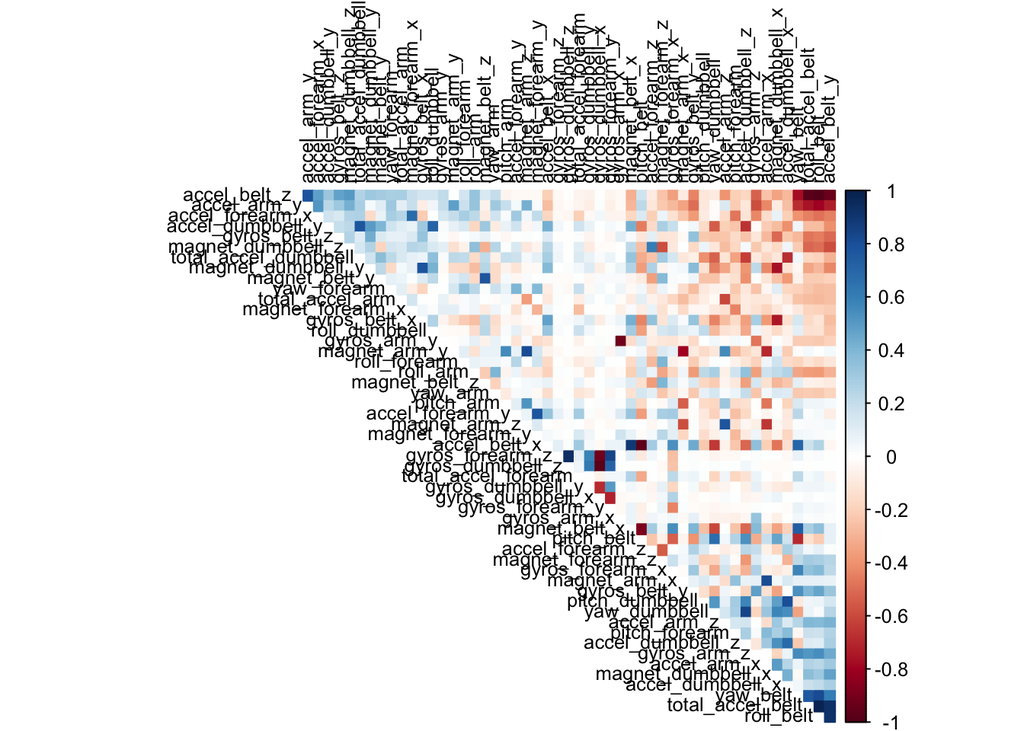

```r
corMatrix <- cor(training[,-53])
corrplot(corMatrix, order = "FPC", method = "color", type = "upper", diag=FALSE,
      tl.cex = 0.8, tl.col = rgb(0, 0, 0))
```

The variables having high correlation are shown in dark colors in the graph. Let’s check how many those variables are ( correlation coefficient is larger than 0.9, which means their VIF larger than 10).

```r
highCorrelated <- findCorrelation(corMatrix, cutoff=0.9)
names(training)[highCorrelated]
```

```
## [1] "accel_belt_z"     "roll_belt"        "accel_belt_y"     "accel_belt_x"
## [5] "gyros_dumbbell_x" "gyros_dumbbell_z" "gyros_arm_x"
```

There are total *7* variables highly correlated. Theoretically, it is better to remove them from data set, or make a Principal Components Analysis (PCA) and build corresponding principal components. In this project, what we concerned is classification prediction and its accuracy. Luckily, the multi-collinearity of data set has no effects on it. Further more, we only have *7* out of *52* predictors having high correlation issue. Therefore, we don’t do de-correlation pre-process in this project.

##### E Double Check Data and Factorizing Classification Dependent Variable

```r
#str(training)
training$classe <- as.factor(training$classe)
```

### IV Build Prediction Models and Get their Accuracy by Cross Validation Method

Four classification models are built by k-folds cross validation on training data set. There are *Decision Tree*, *Random Forest*, *Gradient Boosting Tree* and *Support Vector Machine*.

First, we split *training* data to *train* and *valid* data sets for cross validation. We also setup training control parameter *control*.

```r
inTrain <- createDataPartition(y=training$classe, p=0.7, list=F)
train <- training[inTrain,]
valid <- training[-inTrain,]
control <- trainControl(method="cv", number=3, verboseIter=FALSE)
```

#### 1 Decision Tree Model

[figure not shown]

```r
mod.DT <- train(classe ~ . , data=train, method="rpart", trControl=control, tuneLength=5)
fancyRpartPlot(mod.DT$finalModel)
```

```r
# Prediction on valid data
pred.DT <- predict(mod.DT, valid)
cm.DT <- confusionMatrix(pred.DT, valid$classe)
cm.DT
```

```
## Confusion Matrix and Statistics
##
##           Reference
## Prediction    A    B    C    D    E
##          A 1523  498  489  412  174
##          B   23  319   29    7  115
##          C  101  248  415  135  225
##          D   23   74   93  410   79
##          E    4    0    0    0  489
##
## Overall Statistics
##
##                Accuracy : 0.5363
##                  95% CI : (0.5234, 0.5491)
##     No Information Rate : 0.2845
##     P-Value [Acc > NIR] : < 2.2e-16
##
##                   Kappa : 0.395
##
##  Mcnemar's Test P-Value : < 2.2e-16
##
## Statistics by Class:
##
##                      Class: A Class: B Class: C Class: D Class: E
## Sensitivity            0.9098  0.28007  0.40448  0.42531  0.45194
## Specificity            0.6265  0.96334  0.85409  0.94534  0.99917
## Pos Pred Value         0.4919  0.64706  0.36922  0.60383  0.99189
## Neg Pred Value         0.9459  0.84792  0.87167  0.89358  0.89002
## Prevalence             0.2845  0.19354  0.17434  0.16381  0.18386
## Detection Rate         0.2588  0.05421  0.07052  0.06967  0.08309
## Detection Prevalence   0.5261  0.08377  0.19099  0.11538  0.08377
## Balanced Accuracy      0.7681  0.62170  0.62928  0.68532  0.72555
```

#### 2 Random Forest Model

```r
mod.RF <- train(classe ~ . , data=train, method="rf", trControl=control, tuneLength=5)
mod.RF$finalModel
```

```
##
## Call:
##  randomForest(x = x, y = y, mtry = param$mtry)
##                Type of random forest: classification
##                      Number of trees: 500
## No. of variables tried at each split: 14
##
##         OOB estimate of  error rate: 0.6%
## Confusion matrix:
##      A    B    C    D    E class.error
## A 3900    2    3    0    1 0.001536098
## B   15 2636    7    0    0 0.008276900
## C    0   14 2377    5    0 0.007929883
## D    0    0   26 2225    1 0.011989343
## E    0    0    3    5 2517 0.003168317
```

```r
# Prediction on valid data
pred.RF <- predict(mod.RF, valid)
cm.RF <- confusionMatrix(pred.RF, factor(valid$classe))
cm.RF
```

```
## Confusion Matrix and Statistics
##
##           Reference
## Prediction    A    B    C    D    E
##          A 1672    3    0    0    0
##          B    2 1136    9    0    0
##          C    0    0 1011   15    0
##          D    0    0    6  948    1
##          E    0    0    0    1 1081
##
## Overall Statistics
##
##                Accuracy : 0.9937
##                  95% CI : (0.9913, 0.9956)
##     No Information Rate : 0.2845
##     P-Value [Acc > NIR] : < 2.2e-16
##
##                   Kappa : 0.992
##
##  Mcnemar's Test P-Value : NA
##
## Statistics by Class:
##
##                      Class: A Class: B Class: C Class: D Class: E
## Sensitivity            0.9988   0.9974   0.9854   0.9834   0.9991
## Specificity            0.9993   0.9977   0.9969   0.9986   0.9998
## Pos Pred Value         0.9982   0.9904   0.9854   0.9927   0.9991
## Neg Pred Value         0.9995   0.9994   0.9969   0.9968   0.9998
## Prevalence             0.2845   0.1935   0.1743   0.1638   0.1839
## Detection Rate         0.2841   0.1930   0.1718   0.1611   0.1837
## Detection Prevalence   0.2846   0.1949   0.1743   0.1623   0.1839
## Balanced Accuracy      0.9990   0.9975   0.9911   0.9910   0.9994
```

#### 3 Gradient Boosting Tree Model

```r
mod.GBM <- train(classe ~ . , data=train, method="gbm", trControl=control, tuneLength=5, verbose=FALSE)
mod.GBM$finalModel
```

```
## A gradient boosted model with multinomial loss function.
## 250 iterations were performed.
## There were 52 predictors of which 52 had non-zero influence.
```

```r
# Prediction on valid data
pred.GBM <- predict(mod.GBM, valid)
cm.GBM <- confusionMatrix(pred.GBM, factor(valid$classe))
cm.GBM
```

```
## Confusion Matrix and Statistics
##
##           Reference
## Prediction    A    B    C    D    E
##          A 1669    5    0    0    0
##          B    4 1127   11    0    2
##          C    1    7 1003    7    2
##          D    0    0   10  956    8
##          E    0    0    2    1 1070
##
## Overall Statistics
##
##                Accuracy : 0.9898
##                  95% CI : (0.9869, 0.9922)
##     No Information Rate : 0.2845
##     P-Value [Acc > NIR] : < 2.2e-16
##
##                   Kappa : 0.9871
##
##  Mcnemar's Test P-Value : NA
##
## Statistics by Class:
##
##                      Class: A Class: B Class: C Class: D Class: E
## Sensitivity            0.9970   0.9895   0.9776   0.9917   0.9889
## Specificity            0.9988   0.9964   0.9965   0.9963   0.9994
## Pos Pred Value         0.9970   0.9851   0.9833   0.9815   0.9972
## Neg Pred Value         0.9988   0.9975   0.9953   0.9984   0.9975
## Prevalence             0.2845   0.1935   0.1743   0.1638   0.1839
## Detection Rate         0.2836   0.1915   0.1704   0.1624   0.1818
## Detection Prevalence   0.2845   0.1944   0.1733   0.1655   0.1823
## Balanced Accuracy      0.9979   0.9929   0.9870   0.9940   0.9941
```

#### 4 Support Vector Machine Model

```r
mod.SVM <- train(classe ~ . , data=train, method="svmLinear", trControl=control, tuneLength=5, verbose=FALSE)
mod.SVM$finalModel
```

```
## Support Vector Machine object of class "ksvm"
##
## SV type: C-svc  (classification)
##  parameter : cost C = 1
##
## Linear (vanilla) kernel function.
##
## Number of Support Vectors : 7145
##
## Objective Function Value : -1389.192 -1207.258 -1066.352 -633.5894 -1313.997 -853.972 -1716.116 -1195.26 -1023.072 -1222.324
## Training error : 0.20725
```

```r
# Prediction on valid data
pred.SVM <- predict(mod.SVM, valid)
cm.SVM <- confusionMatrix(pred.SVM, factor(valid$classe))
cm.SVM
```

```
## Confusion Matrix and Statistics
##
##           Reference
## Prediction    A    B    C    D    E
##          A 1530  154   85   54   61
##          B   26  776   81   35  136
##          C   56   78  804  101   59
##          D   51   36   23  730   66
##          E   11   95   33   44  760
##
## Overall Statistics
##
##                Accuracy : 0.7816
##                  95% CI : (0.7709, 0.7921)
##     No Information Rate : 0.2845
##     P-Value [Acc > NIR] : < 2.2e-16
##
##                   Kappa : 0.7226
##
##  Mcnemar's Test P-Value : < 2.2e-16
##
## Statistics by Class:
##
##                      Class: A Class: B Class: C Class: D Class: E
## Sensitivity            0.9140   0.6813   0.7836   0.7573   0.7024
## Specificity            0.9159   0.9414   0.9395   0.9642   0.9619
## Pos Pred Value         0.8121   0.7362   0.7322   0.8057   0.8059
## Neg Pred Value         0.9640   0.9249   0.9536   0.9530   0.9348
## Prevalence             0.2845   0.1935   0.1743   0.1638   0.1839
## Detection Rate         0.2600   0.1319   0.1366   0.1240   0.1291
## Detection Prevalence   0.3201   0.1791   0.1866   0.1540   0.1602
## Balanced Accuracy      0.9150   0.8114   0.8616   0.8607   0.8322
```

#### 5 Accuracy Comparison between Four Classification Models

```r
Accuracy <- data.frame(DecisionTree=cm.DT$overall[1], RandomForest=cm.RF$overall[1],
                       GradientBoostingTree=cm.GBM$overall[1], SupportVectorMachine=cm.SVM$overall[1])
round(Accuracy, 4)
```

```
##          DecisionTree RandomForest GradientBoostingTree SupportVectorMachine
## Accuracy       0.5363       0.9937               0.9898               0.7816
```

We can see the model *RandomForest* gives the highest accuracy of *0.9937* on valid data set. We can plot its confusion matrix. *RandomForest Model* will be used to do prediction on testing data set.

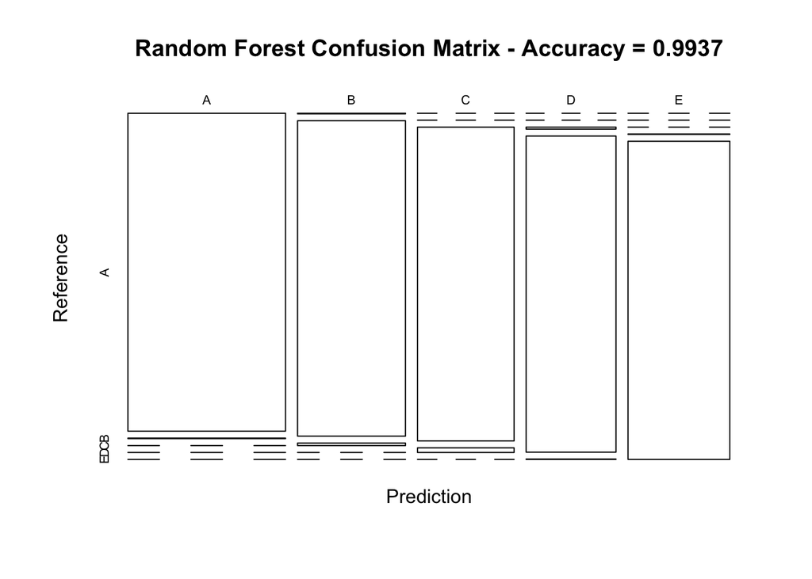

```r
plot(cm.RF$table, col = cm.RF$byClass, main = paste("Random Forest Confusion Matrix - Accuracy =",
                  round(cm.RF$overall['Accuracy'], 4)))
```

### V Prediction of Testing Data by Selected Best Accuracy Model

```r
pred.test.RF <- predict(mod.RF, testing)
pred.test.RF
```

```
##  [1] B A B A A E D B A A B C B A E E A B B B
## Levels: A B C D E
```